# Exercises

Chidi

1/9/2018

### 2.2.1

##### 1. List five functions that you could use to get more information about the mpg dataset.

```r
?mpg # would give me metadata about the dataset
str(mpg) # Internal structure of the object, column name, type, and first few items
```

```
#> Classes 'tbl_df', 'tbl' and 'data.frame':    234 obs. of  11 variables:
#>  $ manufacturer: chr  "audi" "audi" "audi" "audi" ...
#>  $ model       : chr  "a4" "a4" "a4" "a4" ...
#>  $ displ       : num  1.8 1.8 2 2 2.8 2.8 3.1 1.8 1.8 2 ...
#>  $ year        : int  1999 1999 2008 2008 1999 1999 2008 1999 1999 2008 ...
#>  $ cyl         : int  4 4 4 4 6 6 6 4 4 4 ...
#>  $ trans       : chr  "auto(l5)" "manual(m5)" "manual(m6)" "auto(av)" ...
#>  $ drv         : chr  "f" "f" "f" "f" ...
#>  $ cty         : int  18 21 20 21 16 18 18 18 16 20 ...
#>  $ hwy         : int  29 29 31 30 26 26 27 26 25 28 ...
#>  $ fl          : chr  "p" "p" "p" "p" ...
#>  $ class       : chr  "compact" "compact" "compact" "compact" ...
```

```r
# View(mpg) # would show me the full dataset in a clean way
dim(mpg) # would tell me the dimensions of the dataset
```

```
#> [1] 234  11
```

```r
glimpse(mpg) # Similar to `str`. Shows column names, type, and first few items from each column
```

```
#> Observations: 234
#> Variables: 11
#> $ manufacturer <chr> "audi", "audi", "audi", "audi", "audi", "audi", "...
#> $ model        <chr> "a4", "a4", "a4", "a4", "a4", "a4", "a4", "a4 qua...
#> $ displ        <dbl> 1.8, 1.8, 2.0, 2.0, 2.8, 2.8, 3.1, 1.8, 1.8, 2.0,...
#> $ year         <int> 1999, 1999, 2008, 2008, 1999, 1999, 2008, 1999, 1...
#> $ cyl          <int> 4, 4, 4, 4, 6, 6, 6, 4, 4, 4, 4, 6, 6, 6, 6, 6, 6...
#> $ trans        <chr> "auto(l5)", "manual(m5)", "manual(m6)", "auto(av)...
#> $ drv          <chr> "f", "f", "f", "f", "f", "f", "f", "4", "4", "4",...
#> $ cty          <int> 18, 21, 20, 21, 16, 18, 18, 18, 16, 20, 19, 15, 1...
#> $ hwy          <int> 29, 29, 31, 30, 26, 26, 27, 26, 25, 28, 27, 25, 2...
#> $ fl           <chr> "p", "p", "p", "p", "p", "p", "p", "p", "p", "p",...
#> $ class        <chr> "compact", "compact", "compact", "compact", "comp...
```

```r
nrow(mpg) # number of rows
```

```
#> [1] 234
```

```r
ncol(mpg) # number of columns
```

```
#> [1] 11
```

```r
colnames(mpg) # column names. rownames` for row names
```

```
#>  [1] "manufacturer" "model"        "displ"        "year"
#>  [5] "cyl"          "trans"        "drv"          "cty"
#>  [9] "hwy"          "fl"           "class"
```

```r
head(mpg) # top 6 items by default, unless n is specified
```

```
#> # A tibble: 6 x 11
#>   manufacturer model displ  year   cyl trans drv     cty   hwy fl    class
#>   <chr>        <chr> <dbl> <int> <int> <chr> <chr> <int> <int> <chr> <chr>
#> 1 audi         a4     1.80  1999     4 auto~ f        18    29 p     comp~
#> 2 audi         a4     1.80  1999     4 manu~ f        21    29 p     comp~
#> 3 audi         a4     2.00  2008     4 manu~ f        20    31 p     comp~
#> 4 audi         a4     2.00  2008     4 auto~ f        21    30 p     comp~
#> 5 audi         a4     2.80  1999     6 auto~ f        16    26 p     comp~
#> 6 audi         a4     2.80  1999     6 manu~ f        18    26 p     comp~
```

```r
tail(mpg) # bottom 6 items by default, unless n is specified
```

```
#> # A tibble: 6 x 11
#>   manufacturer model displ  year   cyl trans drv     cty   hwy fl    class
#>   <chr>        <chr> <dbl> <int> <int> <chr> <chr> <int> <int> <chr> <chr>
#> 1 volkswagen   pass~  1.80  1999     4 auto~ f        18    29 p     mids~
#> 2 volkswagen   pass~  2.00  2008     4 auto~ f        19    28 p     mids~
#> 3 volkswagen   pass~  2.00  2008     4 manu~ f        21    29 p     mids~
#> 4 volkswagen   pass~  2.80  1999     6 auto~ f        16    26 p     mids~
#> 5 volkswagen   pass~  2.80  1999     6 manu~ f        18    26 p     mids~
#> 6 volkswagen   pass~  3.60  2008     6 auto~ f        17    26 p     mids~
```

##### 2. How can you find out what other datasets are included with ggplot2?

```r
data.frame(data(package = "ggplot2")$results)[-c(1,2)]
```

```
#>              Item
#> 1        diamonds
#> 2       economics
#> 3  economics_long
#> 4       faithfuld
#> 5     luv_colours
#> 6         midwest
#> 7             mpg
#> 8          msleep
#> 9    presidential
#> 10          seals
#> 11      txhousing
#>                                                                Title
#> 1                                Prices of 50,000 round cut diamonds
#> 2                                            US economic time series
#> 3                                            US economic time series
#> 4                           2d density estimate of Old Faithful data
#> 5                                            'colors()' in Luv space
#> 6                                               Midwest demographics
#> 7  Fuel economy data from 1999 and 2008 for 38 popular models of car
#> 8       An updated and expanded version of the mammals sleep dataset
#> 9                    Terms of 11 presidents from Eisenhower to Obama
#> 10                                    Vector field of seal movements
#> 11                                               Housing sales in TX
```

##### 3. Apart from the US, most countries use fuel consumption (fuel consumed over fixed distance) rather than fuel economy (distance travelled with fixed amount of fuel). How could you convert cty and hwy into the European standard of 1/100km?

```r
mpg %>%
  transmute(cty_km = cty * 235.215, hwy_hm = hwy * 235.215)
```

```
#> # A tibble: 234 x 2
#>    cty_km hwy_hm
#>     <dbl>  <dbl>
#>  1   4234   6821
#>  2   4940   6821
#>  3   4704   7292
#>  4   4940   7056
#>  5   3763   6116
#>  6   4234   6116
#>  7   4234   6351
#>  8   4234   6116
#>  9   3763   5880
#> 10   4704   6586
#> # ... with 224 more rows
```

##### 4. Which manufacturer has the most models in this dataset? Which model has the most variations? Does your answer change if you remove the re-dundant specification of drive train (e.g. “pathfinder 4wd”, “a4 quattro”) from the model name?

```r
#==== Manufacturer with most models ========

# This first question is quite confusing for me. What I am answering here is, given the models we have here, which manufacturer has the most models. So for example, a manufacturer can have 3 different types of models in the dataset, like audi has a4, a4 quataro, a6 quattro, and so which manufacturer has the most models in this dataset
mpg %>%
  count(model, manufacturer) %>%
  count(manufacturer, sort = TRUE)
```

```
#> # A tibble: 15 x 2
#>    manufacturer    nn
#>    <chr>        <int>
#>  1 toyota           6
#>  2 chevrolet        4
#>  3 dodge            4
#>  4 ford             4
#>  5 volkswagen       4
#>  6 audi             3
#>  7 nissan           3
#>  8 hyundai          2
#>  9 subaru           2
#> 10 honda            1
#> 11 jeep             1
#> 12 land rover       1
#> 13 lincoln          1
#> 14 mercury          1
#> 15 pontiac          1
```

```r
# Somehow, I also see it as asking, which manufacturer has the most cars (models) in the dataset
mpg %>%
  count(manufacturer, sort = TRUE)
```

```
#> # A tibble: 15 x 2
#>    manufacturer     n
#>    <chr>        <int>
#>  1 dodge           37
#>  2 toyota          34
#>  3 volkswagen      27
#>  4 ford            25
#>  5 chevrolet       19
#>  6 audi            18
#>  7 hyundai         14
#>  8 subaru          14
#>  9 nissan          13
#> 10 honda            9
#> 11 jeep             8
#> 12 pontiac          5
#> 13 land rover       4
#> 14 mercury          4
#> 15 lincoln          3
```

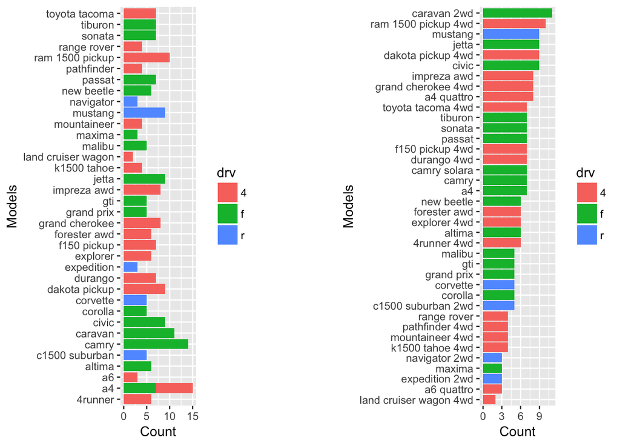

```r
#==== Model with most variations ====
## I'm assuming that by variation, then we mean the `drv` variable

# With re-dundant specification of drive train (e.g. “pathfinder 4wd”, “a4 quattro”)
with_specs = mpg %>%
  count(model, drv, sort = TRUE) %>%
  mutate(fac_model = factor(model, levels = model[order(n)]))
# Without re-dundant specification of drive train (e.g. “pathfinder 4wd”, “a4 quattro”)
# this involves removing 4wd, 2wd, quattro, solara

without_specs = mpg %>%
  mutate(models = gsub(" 4wd| 2wd| quattro| solara", "", model)) %>%
  count(models, drv, sort = TRUE)

with_specs2 = mpg %>%
  count(model, drv, sort = TRUE) %>%
  mutate(fac_model = factor(model, levels = model[order(n)])) %>%
  group_by(fac_model) %>%
  count(fac_model, wt = n, sort = TRUE)

without_specs2 = mpg %>%
  mutate(models = gsub(" 4wd| 2wd| quattro| solara", "", model)) %>%
  count(models, drv, sort = TRUE) %>%
  group_by(models) %>%
  count(models, wt = n, sort = TRUE) %>%
  ungroup() %>%
  mutate(fac_model = factor(models, levels = models[order(nn)]))

# Removing the drive specs changed the variation distributionnslightly

#
ggplot(without_specs, aes(models, n)) +
  geom_col(aes(fill = drv)) +
  coord_flip() +
  ylab("Count") +
  xlab("Models") +
plot_spacer() +
ggplot(with_specs, aes(fac_model, n)) +
  geom_col(aes(fill = drv)) +
  coord_flip() +
  xlab("Models") +
  ylab("Count")
```

One thing to note from the above graph, the model with the highest variation is `a4`, I couldn’t order it because `a4` model has both *4* and *f* `drv` types, so I won’t be able to create the plot above because of that as I’ll like to colour based on `drv`. A better graph would be the one below

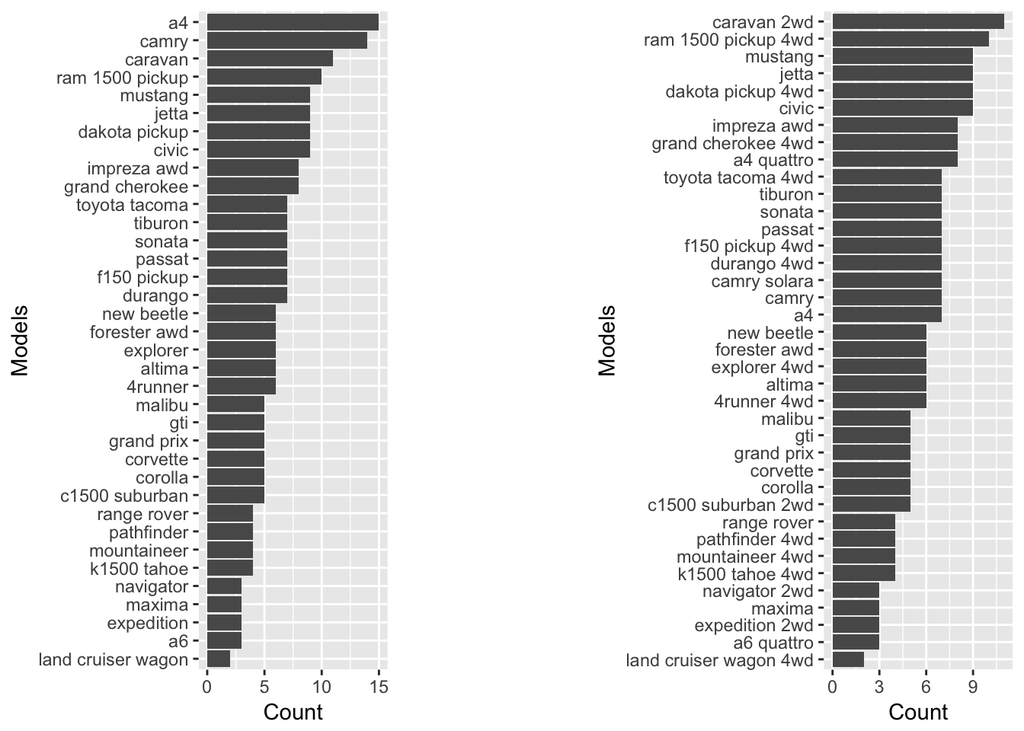

```r
ggplot(without_specs2, aes(fac_model, nn)) +
  geom_col() +
  coord_flip() +
  ylab("Count") +
  xlab("Models") +
plot_spacer() +
ggplot(with_specs2, aes(fac_model, nn)) +
  geom_col() +
  coord_flip() +
  xlab("Models") +
  ylab("Count")
```

### 2.3.1

##### 1. How would you describe the relationship between cty and hwy? Do you have any concerns about drawing conclusions from that plot?

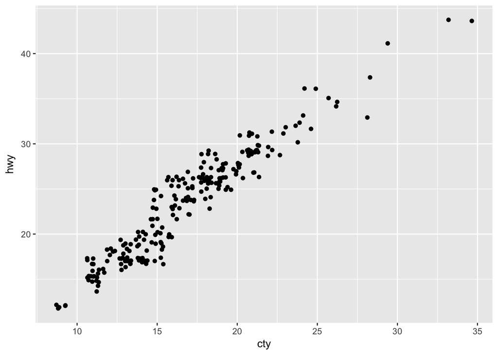

```r
ggplot(mpg, aes(cty, hwy)) +
  geom_jitter()
```

Looking at the plot above, at least it says that the higher the `cty`, the higher the `hwy`. So I don’t really find an outlier here, so I won’t say there’s an issue here. So generally, the lower the *cty* or *hwy*, the better. so a car that has a low *cty* would also have a low *hwy*.

##### 2. What does ggplot(mpg, aes(model, manufacturer)) + geom_point() show? Is it useful? How could you modify the data to make it more informative?

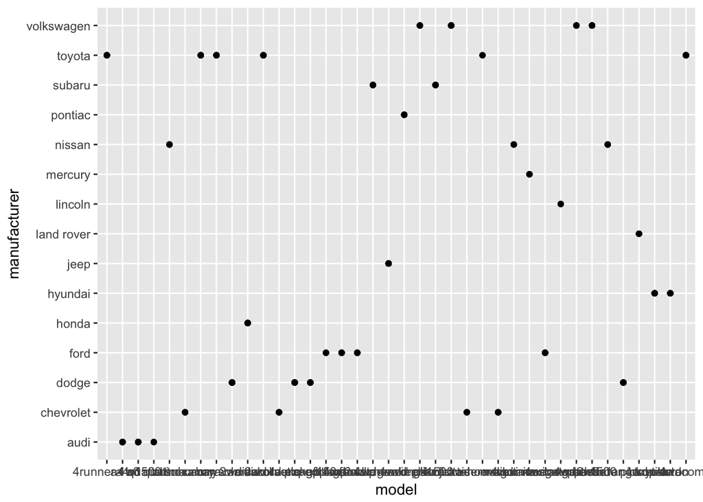

```r
ggplot(mpg, aes(model, manufacturer)) +
  geom_point()
```

Some issues I find with the plot, first, its not easy to understand what’s the x axis labels are (unless I coord_flip), secondly, the variables together for this kind of plot isn’t really intuitive (so ideally, I’ll change the kind of geom I’m using here). Some changes I can is to reduce the number of categories on congested axis (like removing the drv specifications in the model variable), or flip the plot (or rotate the x axis), create a map for the congested axis categories, the keys being shorter names that would be shown on the plot.

##### 3. Describe the data, aesthetic mappings and layers used for each of the following plots. You’ll need to guess a little because you haven’t seen all the datasets and functions yet, but use your common sense! See if you can predict what the plot will look like before running the code.

1. ggplot(mpg, aes(cty, hwy)) + geom_point()
2. ggplot(diamonds, aes(carat, price)) + geom_point()
3. ggplot(economics, aes(date, unemploy)) + geom_line()
4. ggplot(mpg, aes(cty)) + geom_histogram()

1 **data** = *mpg*, **aestistic mapping** = *cty* and *hwy*, **layers** = `geom_point`  
2 **data** = *diamonds*, **aestistic mapping** = *carat* and *price*, **layers** = `geom_point`  
3 **data** = *economics*, **aestistic mapping** = *date* and *unemploy*, **layers** = `geom_line`  
4 **data** = *mpg*, **aestistic mapping** = *cty*, **layers** = `geom_histogram`

### 2.4.1

##### 1. Experiment with the colour, shape and size aesthetics. What happens when you map them to continuous values? What about categorical values? What happens when you use more than one aesthetic in a plot?

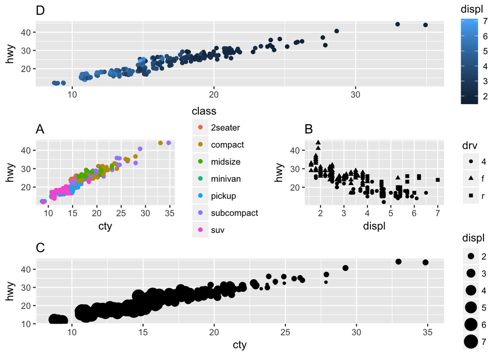

```r
p1 <- ggplot(mpg, aes(cty, hwy, colour = class)) +
  geom_jitter() + ggtitle("A")
p2 <- ggplot(mpg, aes(displ, hwy, shape = drv)) +
  geom_point() + ggtitle("B")
p3 <- ggplot(mpg, aes(cty, hwy, size = displ)) +
  geom_jitter() + ggtitle("C")
p4 <- ggplot(mpg, aes(cty, hwy, colour = displ)) +
  geom_jitter() +
  ggtitle("D")

(p4 + (p1 + p2) + p3  + plot_layout(ncol = 1))
```

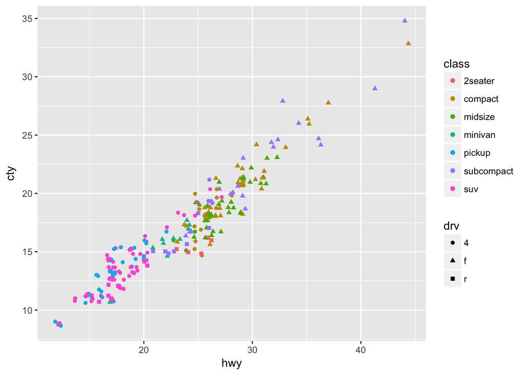

```r
ggplot(mpg, aes(hwy, cty, colour = class, shape = drv)) +
  geom_jitter()
```

When I try to map a continuous variable to a shape aestistic property, it throws an error, also, mapping a shape to a variable with lots of categories wouldn’t scale all categories, and so we’ll see categories that are empty. However, if we map a colour to a continuous variable, it can be useful depending on how we see it, as it produces a colour pallete scale for the continuous variable, ans shows how this is mapped in the legend. Applying more than one aestistic property mapping still returns a legend of the scaling used for each of the aestistic mapping.

##### 2. What happens if you map a continuous variable to shape? Why? What happens if you map trans to shape? Why?

Mapping a continuous variable to a shape throws an error, this could be because there’s not enough shapes to scale the continuous variable

```
#> Warning: The shape palette can deal with a maximum of 6 discrete values
#> because more than 6 becomes difficult to discriminate; you have
#> 10. Consider specifying shapes manually if you must have them.
#> Warning: Removed 96 rows containing missing values (geom_point).
```

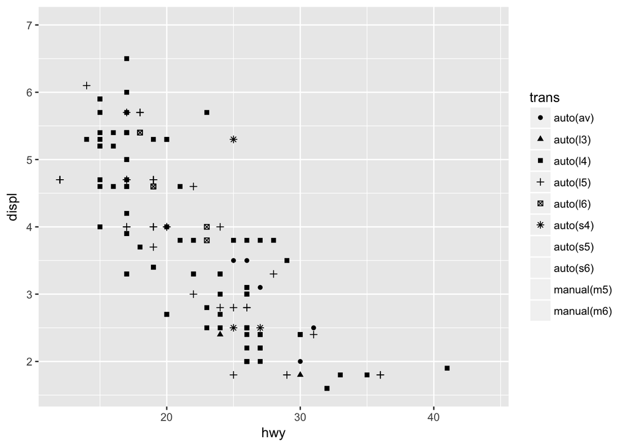

```r
ggplot(mpg, aes(hwy, displ, shape = trans)) +
  geom_point()
```

Mapping *trans* variable to a shape creates a legend that shows that it couldn’t scale all trans categories to shapes as seen in the empty categories on the legend, it then shows a warning explaining why, basically because it couldn’t map the categories to a shape pallete, as there’re more categories than the required number of shapes in the shape pallete (6 by default).

##### 3. How is drive train related to fuel economy? How is drive train related to engine size and class?

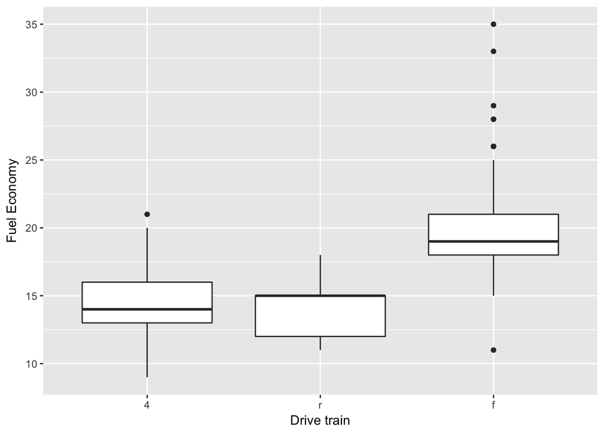

```r
ggplot(mpg, aes(reorder(drv, cty, FUN = median), cty)) +
  geom_boxplot() +
  xlab("Drive train") +
  ylab("Fuel Economy")
```

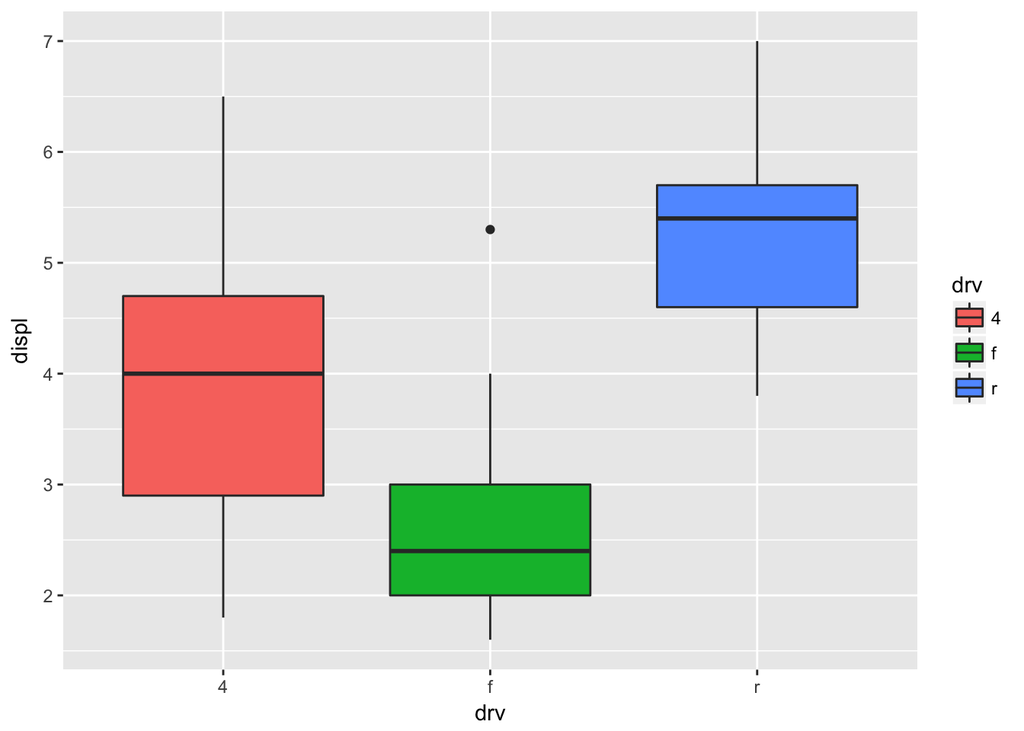

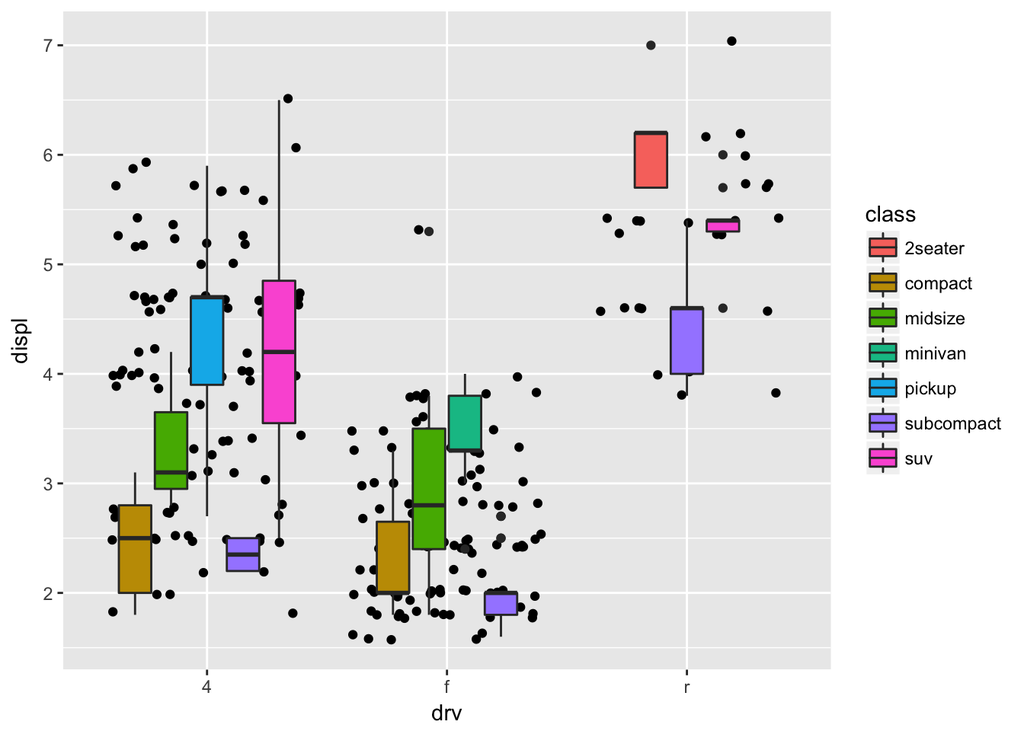

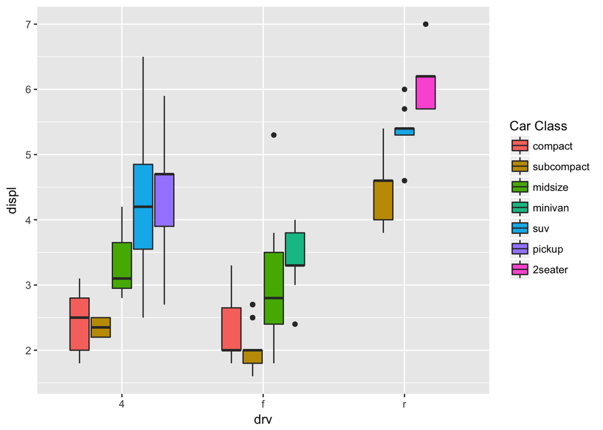

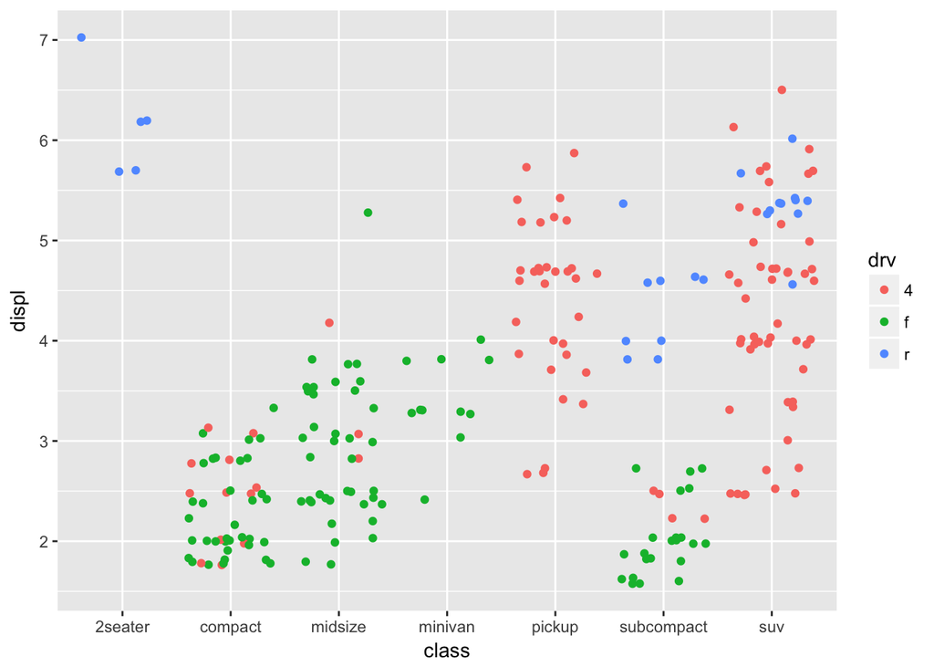

```r
p1 <- ggplot(mpg, aes(drv, displ)) +
  geom_boxplot(aes(fill = drv))

p2 <- ggplot(mpg, aes(drv, displ)) +
  geom_jitter() +
  geom_boxplot(aes(fill = class))

p3 <- ggplot(mpg, aes(drv, displ)) +
  geom_boxplot(aes(fill = reorder(class, displ, FUN = median))) +
  labs(fill = "Car Class")

p4 <- ggplot(mpg, aes(class, displ)) +
  geom_jitter(aes(colour = drv))

# p1 + p2 + p3 + p4  + plot_layout(ncol = 1)
p1;p2;p3;p4
```

From the above, I see that Front weel drive (f) has the best fuel economy (cty, although, hwy would provide the same result). I see that, for all drive train types, subcompat and compat cars usually have the least engine displacement. Also, for 2 seater buses, there’re mostly rear wheeled cars, and rear wheeled cars has the highest engine displacement